# Risk Factor Analysis

## Outcome Variable

**Outcome Variable:** sstunted

## Predictor Variables

**Intervention Variable:** enstunt

**Adjustment Set:**

- arm
- sex
- W_mage
- meducyrs
- feducyrs
- vagbrth
- single
- brthmon
- W_parity
- impsan
- delta_W_mage
- delta_meducyrs
- delta_feducyrs
- delta_vagbrth
- delta_single
- delta_brthmon
- delta_W_parity
- delta_impsan

## Stratifying Variables

The analysis was stratified on these variable(s):

- agecat
- studyid
- country

## Data Summary

| agecat | studyid | country | enstunt | sstunted | n_cell | n |
| --- | --- | --- | --- | --- | --- | --- |
| Birth | ki0047075b-MAL-ED | BANGLADESH | 0 | 0 | 187 | 231 |
| Birth | ki0047075b-MAL-ED | BANGLADESH | 0 | 1 | 0 | 231 |
| Birth | ki0047075b-MAL-ED | BANGLADESH | 1 | 0 | 35 | 231 |
| Birth | ki0047075b-MAL-ED | BANGLADESH | 1 | 1 | 9 | 231 |
| Birth | ki0047075b-MAL-ED | BRAZIL | 0 | 0 | 56 | 65 |
| Birth | ki0047075b-MAL-ED | BRAZIL | 0 | 1 | 0 | 65 |
| Birth | ki0047075b-MAL-ED | BRAZIL | 1 | 0 | 6 | 65 |
| Birth | ki0047075b-MAL-ED | BRAZIL | 1 | 1 | 3 | 65 |
| Birth | ki0047075b-MAL-ED | INDIA | 0 | 0 | 37 | 47 |
| Birth | ki0047075b-MAL-ED | INDIA | 0 | 1 | 0 | 47 |
| Birth | ki0047075b-MAL-ED | INDIA | 1 | 0 | 8 | 47 |
| Birth | ki0047075b-MAL-ED | INDIA | 1 | 1 | 2 | 47 |
| Birth | ki0047075b-MAL-ED | NEPAL | 0 | 0 | 25 | 27 |
| Birth | ki0047075b-MAL-ED | NEPAL | 0 | 1 | 0 | 27 |
| Birth | ki0047075b-MAL-ED | NEPAL | 1 | 0 | 1 | 27 |
| Birth | ki0047075b-MAL-ED | NEPAL | 1 | 1 | 1 | 27 |
| Birth | ki0047075b-MAL-ED | PERU | 0 | 0 | 207 | 233 |
| Birth | ki0047075b-MAL-ED | PERU | 0 | 1 | 0 | 233 |
| Birth | ki0047075b-MAL-ED | PERU | 1 | 0 | 22 | 233 |
| Birth | ki0047075b-MAL-ED | PERU | 1 | 1 | 4 | 233 |
| Birth | ki0047075b-MAL-ED | SOUTH AFRICA | 0 | 0 | 113 | 123 |
| Birth | ki0047075b-MAL-ED | SOUTH AFRICA | 0 | 1 | 0 | 123 |
| Birth | ki0047075b-MAL-ED | SOUTH AFRICA | 1 | 0 | 8 | 123 |
| Birth | ki0047075b-MAL-ED | SOUTH AFRICA | 1 | 1 | 2 | 123 |
| Birth | ki0047075b-MAL-ED | TANZANIA, UNITED REPUBLIC OF | 0 | 0 | 102 | 125 |
| Birth | ki0047075b-MAL-ED | TANZANIA, UNITED REPUBLIC OF | 0 | 1 | 0 | 125 |
| Birth | ki0047075b-MAL-ED | TANZANIA, UNITED REPUBLIC OF | 1 | 0 | 13 | 125 |
| Birth | ki0047075b-MAL-ED | TANZANIA, UNITED REPUBLIC OF | 1 | 1 | 10 | 125 |
| Birth | ki1000108-CMC-V-BCS-2002 | INDIA | 0 | 0 | 75 | 92 |
| Birth | ki1000108-CMC-V-BCS-2002 | INDIA | 0 | 1 | 0 | 92 |

[output cut: 298 more lines]

The following strata were considered:

- agecat: 24 months, studyid: ki0047075b-MAL-ED, country: BANGLADESH
- agecat: 24 months, studyid: ki0047075b-MAL-ED, country: BRAZIL
- agecat: 24 months, studyid: ki0047075b-MAL-ED, country: INDIA
- agecat: 24 months, studyid: ki0047075b-MAL-ED, country: NEPAL
- agecat: 24 months, studyid: ki0047075b-MAL-ED, country: PERU
- agecat: 24 months, studyid: ki0047075b-MAL-ED, country: SOUTH AFRICA
- agecat: 24 months, studyid: ki0047075b-MAL-ED, country: TANZANIA, UNITED REPUBLIC OF
- agecat: 24 months, studyid: ki1000108-CMC-V-BCS-2002, country: INDIA
- agecat: 24 months, studyid: ki1000108-IRC, country: INDIA
- agecat: 24 months, studyid: ki1000109-EE, country: PAKISTAN
- agecat: 24 months, studyid: ki1017093-NIH-Birth, country: BANGLADESH
- agecat: 24 months, studyid: ki1017093b-PROVIDE, country: BANGLADESH
- agecat: 24 months, studyid: ki1017093c-NIH-Crypto, country: BANGLADESH
- agecat: 24 months, studyid: ki1066203-TanzaniaChild2, country: TANZANIA, UNITED REPUBLIC OF
- agecat: 24 months, studyid: ki1101329-Keneba, country: GAMBIA
- agecat: 24 months, studyid: ki1113344-GMS-Nepal, country: NEPAL
- agecat: 24 months, studyid: ki1114097-CMIN, country: BANGLADESH
- agecat: 24 months, studyid: ki1114097-CONTENT, country: PERU
- agecat: 24 months, studyid: ki1119695-PROBIT, country: BELARUS
- agecat: 24 months, studyid: ki1126311-ZVITAMBO, country: ZIMBABWE
- agecat: 24 months, studyid: ki1135781-COHORTS, country: GUATEMALA
- agecat: 24 months, studyid: ki1135781-COHORTS, country: INDIA
- agecat: 24 months, studyid: ki1135781-COHORTS, country: PHILIPPINES
- agecat: 24 months, studyid: ki1148112-LCNI-5, country: MALAWI
- agecat: 24 months, studyid: kiGH5241-JiVitA-3, country: BANGLADESH
- agecat: 24 months, studyid: kiGH5241-JiVitA-4, country: BANGLADESH
- agecat: 6 months, studyid: ki0047075b-MAL-ED, country: BANGLADESH
- agecat: 6 months, studyid: ki0047075b-MAL-ED, country: BRAZIL
- agecat: 6 months, studyid: ki0047075b-MAL-ED, country: INDIA
- agecat: 6 months, studyid: ki0047075b-MAL-ED, country: NEPAL
- agecat: 6 months, studyid: ki0047075b-MAL-ED, country: PERU
- agecat: 6 months, studyid: ki0047075b-MAL-ED, country: SOUTH AFRICA
- agecat: 6 months, studyid: ki0047075b-MAL-ED, country: TANZANIA, UNITED REPUBLIC OF
- agecat: 6 months, studyid: ki1000108-CMC-V-BCS-2002, country: INDIA
- agecat: 6 months, studyid: ki1000108-IRC, country: INDIA
- agecat: 6 months, studyid: ki1000109-EE, country: PAKISTAN
- agecat: 6 months, studyid: ki1000109-ResPak, country: PAKISTAN
- agecat: 6 months, studyid: ki1000304b-SAS-CompFeed, country: INDIA
- agecat: 6 months, studyid: ki1000304b-SAS-FoodSuppl, country: INDIA
- agecat: 6 months, studyid: ki1017093-NIH-Birth, country: BANGLADESH
- agecat: 6 months, studyid: ki1017093b-PROVIDE, country: BANGLADESH
- agecat: 6 months, studyid: ki1017093c-NIH-Crypto, country: BANGLADESH
- agecat: 6 months, studyid: ki1066203-TanzaniaChild2, country: TANZANIA, UNITED REPUBLIC OF
- agecat: 6 months, studyid: ki1101329-Keneba, country: GAMBIA
- agecat: 6 months, studyid: ki1112895-Guatemala BSC, country: GUATEMALA
- agecat: 6 months, studyid: ki1113344-GMS-Nepal, country: NEPAL
- agecat: 6 months, studyid: ki1114097-CMIN, country: BANGLADESH
- agecat: 6 months, studyid: ki1114097-CONTENT, country: PERU
- agecat: 6 months, studyid: ki1119695-PROBIT, country: BELARUS
- agecat: 6 months, studyid: ki1126311-ZVITAMBO, country: ZIMBABWE
- agecat: 6 months, studyid: ki1135781-COHORTS, country: GUATEMALA
- agecat: 6 months, studyid: ki1135781-COHORTS, country: INDIA
- agecat: 6 months, studyid: ki1135781-COHORTS, country: PHILIPPINES
- agecat: 6 months, studyid: ki1148112-LCNI-5, country: MALAWI
- agecat: 6 months, studyid: kiGH5241-JiVitA-3, country: BANGLADESH
- agecat: 6 months, studyid: kiGH5241-JiVitA-4, country: BANGLADESH
- agecat: Birth, studyid: ki0047075b-MAL-ED, country: BANGLADESH
- agecat: Birth, studyid: ki0047075b-MAL-ED, country: BRAZIL
- agecat: Birth, studyid: ki0047075b-MAL-ED, country: INDIA
- agecat: Birth, studyid: ki0047075b-MAL-ED, country: NEPAL
- agecat: Birth, studyid: ki0047075b-MAL-ED, country: PERU
- agecat: Birth, studyid: ki0047075b-MAL-ED, country: SOUTH AFRICA
- agecat: Birth, studyid: ki0047075b-MAL-ED, country: TANZANIA, UNITED REPUBLIC OF
- agecat: Birth, studyid: ki1000108-CMC-V-BCS-2002, country: INDIA
- agecat: Birth, studyid: ki1000108-IRC, country: INDIA
- agecat: Birth, studyid: ki1000109-EE, country: PAKISTAN
- agecat: Birth, studyid: ki1000109-ResPak, country: PAKISTAN
- agecat: Birth, studyid: ki1000304b-SAS-CompFeed, country: INDIA
- agecat: Birth, studyid: ki1017093-NIH-Birth, country: BANGLADESH
- agecat: Birth, studyid: ki1017093b-PROVIDE, country: BANGLADESH
- agecat: Birth, studyid: ki1017093c-NIH-Crypto, country: BANGLADESH
- agecat: Birth, studyid: ki1101329-Keneba, country: GAMBIA
- agecat: Birth, studyid: ki1113344-GMS-Nepal, country: NEPAL
- agecat: Birth, studyid: ki1114097-CMIN, country: BANGLADESH
- agecat: Birth, studyid: ki1114097-CONTENT, country: PERU
- agecat: Birth, studyid: ki1119695-PROBIT, country: BELARUS
- agecat: Birth, studyid: ki1126311-ZVITAMBO, country: ZIMBABWE
- agecat: Birth, studyid: ki1135781-COHORTS, country: GUATEMALA
- agecat: Birth, studyid: ki1135781-COHORTS, country: INDIA
- agecat: Birth, studyid: ki1135781-COHORTS, country: PHILIPPINES
- agecat: Birth, studyid: kiGH5241-JiVitA-3, country: BANGLADESH
- agecat: Birth, studyid: kiGH5241-JiVitA-4, country: BANGLADESH

### Dropped Strata

Some strata were dropped due to rare outcomes:

- agecat: Birth, studyid: ki0047075b-MAL-ED, country: BANGLADESH
- agecat: Birth, studyid: ki0047075b-MAL-ED, country: BRAZIL
- agecat: Birth, studyid: ki0047075b-MAL-ED, country: INDIA
- agecat: Birth, studyid: ki0047075b-MAL-ED, country: NEPAL
- agecat: Birth, studyid: ki0047075b-MAL-ED, country: PERU
- agecat: Birth, studyid: ki0047075b-MAL-ED, country: SOUTH AFRICA
- agecat: Birth, studyid: ki0047075b-MAL-ED, country: TANZANIA, UNITED REPUBLIC OF
- agecat: Birth, studyid: ki1000108-CMC-V-BCS-2002, country: INDIA
- agecat: Birth, studyid: ki1000108-IRC, country: INDIA
- agecat: Birth, studyid: ki1000109-EE, country: PAKISTAN
- agecat: Birth, studyid: ki1000109-ResPak, country: PAKISTAN
- agecat: Birth, studyid: ki1000304b-SAS-CompFeed, country: INDIA
- agecat: Birth, studyid: ki1017093-NIH-Birth, country: BANGLADESH
- agecat: Birth, studyid: ki1017093b-PROVIDE, country: BANGLADESH
- agecat: Birth, studyid: ki1017093c-NIH-Crypto, country: BANGLADESH
- agecat: Birth, studyid: ki1101329-Keneba, country: GAMBIA
- agecat: Birth, studyid: ki1113344-GMS-Nepal, country: NEPAL
- agecat: Birth, studyid: ki1114097-CMIN, country: BANGLADESH
- agecat: Birth, studyid: ki1114097-CONTENT, country: PERU
- agecat: Birth, studyid: ki1119695-PROBIT, country: BELARUS
- agecat: Birth, studyid: ki1126311-ZVITAMBO, country: ZIMBABWE
- agecat: Birth, studyid: ki1135781-COHORTS, country: GUATEMALA
- agecat: Birth, studyid: ki1135781-COHORTS, country: INDIA
- agecat: Birth, studyid: ki1135781-COHORTS, country: PHILIPPINES
- agecat: Birth, studyid: kiGH5241-JiVitA-3, country: BANGLADESH
- agecat: Birth, studyid: kiGH5241-JiVitA-4, country: BANGLADESH
- agecat: 6 months, studyid: ki0047075b-MAL-ED, country: BANGLADESH
- agecat: 6 months, studyid: ki0047075b-MAL-ED, country: BRAZIL
- agecat: 6 months, studyid: ki0047075b-MAL-ED, country: INDIA
- agecat: 6 months, studyid: ki0047075b-MAL-ED, country: NEPAL
- agecat: 6 months, studyid: ki0047075b-MAL-ED, country: PERU
- agecat: 6 months, studyid: ki0047075b-MAL-ED, country: SOUTH AFRICA
- agecat: 6 months, studyid: ki1000304b-SAS-FoodSuppl, country: INDIA
- agecat: 6 months, studyid: ki1112895-Guatemala BSC, country: GUATEMALA
- agecat: 6 months, studyid: ki1114097-CMIN, country: BANGLADESH
- agecat: 6 months, studyid: ki1114097-CONTENT, country: PERU
- agecat: 6 months, studyid: ki1148112-LCNI-5, country: MALAWI
- agecat: 24 months, studyid: ki0047075b-MAL-ED, country: BRAZIL
- agecat: 24 months, studyid: ki0047075b-MAL-ED, country: NEPAL
- agecat: 24 months, studyid: ki0047075b-MAL-ED, country: SOUTH AFRICA
- agecat: 24 months, studyid: ki1066203-TanzaniaChild2, country: TANZANIA, UNITED REPUBLIC OF
- agecat: 24 months, studyid: ki1114097-CONTENT, country: PERU
- agecat: 24 months, studyid: ki1119695-PROBIT, country: BELARUS

## Methods Detail

We’re interested in the causal parameters $E[Y_a]$ for all values of $a \in \mathcal{A}$. These parameters represent the mean outcome if, possibly contrary to fact, we intervened to set all units to have $A=a$. Under the randomization and positivity assumptions, these are identified by the statistical parameters $\psi_a=E_W[E_{Y|A,W}(Y|A=a,W)]$. In addition, we’re interested in the mean of $Y$, $E[Y]$ under no intervention (the observed mean). We will estimate these parameters by using SuperLearner to fit the relevant likelihood factors – $E_{Y|A,W}(Y|A=a,W)$ and $p(A=a|W)$, and then updating our likelihood fit using a joint TMLE.

For unadjusted analyses ($W=\{\}$), initial likelihoods were estimated using Lrnr_glm to estimate the simple $E(Y|A)$ and Lrnr_mean to estimate $p(A)$. For adjusted analyses, a small library containing Lrnr_glmnet, Lrnr_xgboost, and Lrnr_mean was used.

Having estimated these parameters, we will then use the delta method to estimate relative risks and attributable risks relative to a prespecified baseline level of $A$.

# Results Detail

## Results Plots

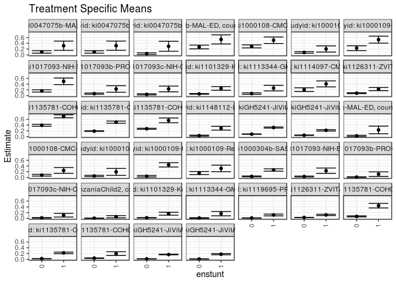

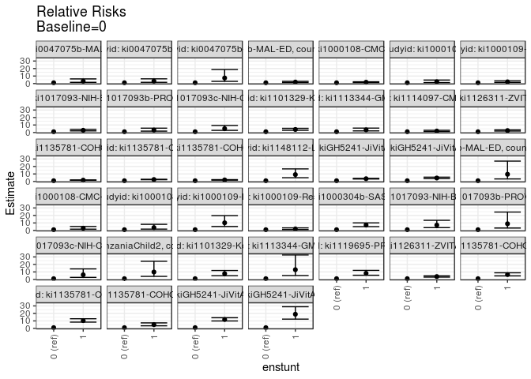

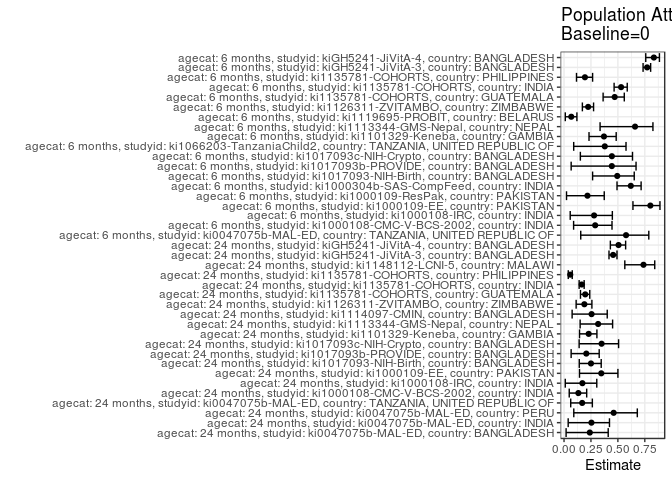

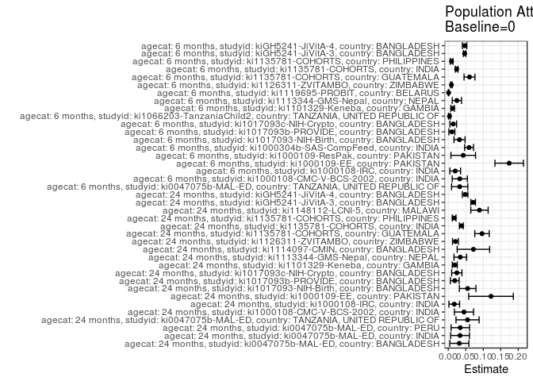

## Results Table

### Parameter: TSM

| agecat | studyid | country | intervention_level | baseline_level | estimate | ci_lower | ci_upper |
| --- | --- | --- | --- | --- | --- | --- | --- |
| 6 months | ki0047075b-MAL-ED | TANZANIA, UNITED REPUBLIC OF | 0 | NA | 0.0240385 | 0.0031807 | 0.0448962 |
| 6 months | ki0047075b-MAL-ED | TANZANIA, UNITED REPUBLIC OF | 1 | NA | 0.2307692 | 0.0982698 | 0.3632687 |
| 6 months | ki1000108-CMC-V-BCS-2002 | INDIA | 0 | NA | 0.0808983 | 0.0495188 | 0.1122779 |
| 6 months | ki1000108-CMC-V-BCS-2002 | INDIA | 1 | NA | 0.2439883 | 0.1440974 | 0.3438791 |
| 6 months | ki1000108-IRC | INDIA | 0 | NA | 0.0513651 | 0.0284753 | 0.0742550 |
| 6 months | ki1000108-IRC | INDIA | 1 | NA | 0.1953798 | 0.0737055 | 0.3170541 |
| 6 months | ki1000109-EE | PAKISTAN | 0 | NA | 0.0430622 | 0.0155042 | 0.0706202 |
| 6 months | ki1000109-EE | PAKISTAN | 1 | NA | 0.4390244 | 0.3629698 | 0.5150790 |
| 6 months | ki1000109-ResPak | PAKISTAN | 0 | NA | 0.1538576 | 0.0999384 | 0.2077769 |
| 6 months | ki1000109-ResPak | PAKISTAN | 1 | NA | 0.3140018 | 0.1993348 | 0.4286688 |
| 6 months | ki1000304b-SAS-CompFeed | INDIA | 0 | NA | 0.0364047 | 0.0219137 | 0.0508958 |
| 6 months | ki1000304b-SAS-CompFeed | INDIA | 1 | NA | 0.2608152 | 0.2214477 | 0.3001826 |
| 6 months | ki1017093-NIH-Birth | BANGLADESH | 0 | NA | 0.0329600 | 0.0164951 | 0.0494249 |
| 6 months | ki1017093-NIH-Birth | BANGLADESH | 1 | NA | 0.2349638 | 0.1413016 | 0.3286260 |
| 6 months | ki1017093b-PROVIDE | BANGLADESH | 0 | NA | 0.0128913 | 0.0033954 | 0.0223873 |
| 6 months | ki1017093b-PROVIDE | BANGLADESH | 1 | NA | 0.1147541 | 0.0347045 | 0.1948037 |
| 6 months | ki1017093c-NIH-Crypto | BANGLADESH | 0 | NA | 0.0178775 | 0.0073488 | 0.0284063 |
| 6 months | ki1017093c-NIH-Crypto | BANGLADESH | 1 | NA | 0.1101701 | 0.0468441 | 0.1734962 |
| 6 months | ki1066203-TanzaniaChild2 | TANZANIA, UNITED REPUBLIC OF | 0 | NA | 0.0058201 | 0.0023899 | 0.0092503 |
| 6 months | ki1066203-TanzaniaChild2 | TANZANIA, UNITED REPUBLIC OF | 1 | NA | 0.0575540 | 0.0188270 | 0.0962809 |
| 6 months | ki1101329-Keneba | GAMBIA | 0 | NA | 0.0210867 | 0.0145940 | 0.0275794 |
| 6 months | ki1101329-Keneba | GAMBIA | 1 | NA | 0.1619866 | 0.1110752 | 0.2128980 |
| 6 months | ki1113344-GMS-Nepal | NEPAL | 0 | NA | 0.0126850 | 0.0025907 | 0.0227793 |
| 6 months | ki1113344-GMS-Nepal | NEPAL | 1 | NA | 0.1648352 | 0.0885353 | 0.2411350 |
| 6 months | ki1119695-PROBIT | BELARUS | 0 | NA | 0.0143812 | 0.0090749 | 0.0196876 |
| 6 months | ki1119695-PROBIT | BELARUS | 1 | NA | 0.1177713 | 0.0873417 | 0.1482009 |
| 6 months | ki1126311-ZVITAMBO | ZIMBABWE | 0 | NA | 0.0314158 | 0.0275497 | 0.0352819 |
| 6 months | ki1126311-ZVITAMBO | ZIMBABWE | 1 | NA | 0.1198997 | 0.0982174 | 0.1415821 |
| 6 months | ki1135781-COHORTS | GUATEMALA | 0 | NA | 0.0683551 | 0.0509556 | 0.0857545 |
| 6 months | ki1135781-COHORTS | GUATEMALA | 1 | NA | 0.4423437 | 0.3620390 | 0.5226484 |
| 6 months | ki1135781-COHORTS | INDIA | 0 | NA | 0.0213116 | 0.0176693 | 0.0249538 |
| 6 months | ki1135781-COHORTS | INDIA | 1 | NA | 0.2213937 | 0.1930079 | 0.2497794 |
| 6 months | ki1135781-COHORTS | PHILIPPINES | 0 | NA | 0.0392844 | 0.0317463 | 0.0468225 |
| 6 months | ki1135781-COHORTS | PHILIPPINES | 1 | NA | 0.1975237 | 0.1329620 | 0.2620854 |
| 6 months | kiGH5241-JiVitA-3 | BANGLADESH | 0 | NA | 0.0138464 | 0.0114561 | 0.0162366 |
| 6 months | kiGH5241-JiVitA-3 | BANGLADESH | 1 | NA | 0.1646737 | 0.1542853 | 0.1750622 |
| 6 months | kiGH5241-JiVitA-4 | BANGLADESH | 0 | NA | 0.0093030 | 0.0055221 | 0.0130839 |
| 6 months | kiGH5241-JiVitA-4 | BANGLADESH | 1 | NA | 0.1758096 | 0.1549363 | 0.1966828 |
| 24 months | ki0047075b-MAL-ED | BANGLADESH | 0 | NA | 0.1004552 | 0.0562940 | 0.1446163 |
| 24 months | ki0047075b-MAL-ED | BANGLADESH | 1 | NA | 0.3151927 | 0.1538129 | 0.4765724 |
| 24 months | ki0047075b-MAL-ED | INDIA | 0 | NA | 0.0985173 | 0.0559355 | 0.1410990 |
| 24 months | ki0047075b-MAL-ED | INDIA | 1 | NA | 0.3164776 | 0.1566003 | 0.4763549 |
| 24 months | ki0047075b-MAL-ED | PERU | 0 | NA | 0.0402299 | 0.0109604 | 0.0694993 |
| 24 months | ki0047075b-MAL-ED | PERU | 1 | NA | 0.2962963 | 0.1236301 | 0.4689625 |
| 24 months | ki0047075b-MAL-ED | TANZANIA, UNITED REPUBLIC OF | 0 | NA | 0.2719516 | 0.2065221 | 0.3373812 |
| 24 months | ki0047075b-MAL-ED | TANZANIA, UNITED REPUBLIC OF | 1 | NA | 0.5340914 | 0.3757269 | 0.6924560 |
| 24 months | ki1000108-CMC-V-BCS-2002 | INDIA | 0 | NA | 0.2920595 | 0.2397793 | 0.3443398 |
| 24 months | ki1000108-CMC-V-BCS-2002 | INDIA | 1 | NA | 0.5068464 | 0.3934752 | 0.6202176 |
| 24 months | ki1000108-IRC | INDIA | 0 | NA | 0.0831429 | 0.0546263 | 0.1116595 |
| 24 months | ki1000108-IRC | INDIA | 1 | NA | 0.2025977 | 0.0946213 | 0.3105740 |
| 24 months | ki1000109-EE | PAKISTAN | 0 | NA | 0.2310972 | 0.1475853 | 0.3146091 |
| 24 months | ki1000109-EE | PAKISTAN | 1 | NA | 0.5270729 | 0.4052684 | 0.6488774 |
| 24 months | ki1017093-NIH-Birth | BANGLADESH | 0 | NA | 0.1660320 | 0.1272208 | 0.2048432 |
| 24 months | ki1017093-NIH-Birth | BANGLADESH | 1 | NA | 0.4990347 | 0.3838021 | 0.6142674 |
| 24 months | ki1017093b-PROVIDE | BANGLADESH | 0 | NA | 0.0713492 | 0.0491228 | 0.0935757 |
| 24 months | ki1017093b-PROVIDE | BANGLADESH | 1 | NA | 0.2333296 | 0.1201473 | 0.3465118 |
| 24 months | ki1017093c-NIH-Crypto | BANGLADESH | 0 | NA | 0.0456146 | 0.0262563 | 0.0649730 |
| 24 months | ki1017093c-NIH-Crypto | BANGLADESH | 1 | NA | 0.2353412 | 0.1359726 | 0.3347099 |
| 24 months | ki1101329-Keneba | GAMBIA | 0 | NA | 0.0625898 | 0.0505092 | 0.0746704 |
| 24 months | ki1101329-Keneba | GAMBIA | 1 | NA | 0.2524123 | 0.1878699 | 0.3169547 |
| 24 months | ki1113344-GMS-Nepal | NEPAL | 0 | NA | 0.0742095 | 0.0487276 | 0.0996915 |
| 24 months | ki1113344-GMS-Nepal | NEPAL | 1 | NA | 0.2636130 | 0.1658970 | 0.3613290 |
| 24 months | ki1114097-CMIN | BANGLADESH | 0 | NA | 0.2091070 | 0.1443497 | 0.2738643 |
| 24 months | ki1114097-CMIN | BANGLADESH | 1 | NA | 0.4094053 | 0.3053835 | 0.5134271 |
| 24 months | ki1126311-ZVITAMBO | ZIMBABWE | 0 | NA | 0.0880348 | 0.0732561 | 0.1028135 |
| 24 months | ki1126311-ZVITAMBO | ZIMBABWE | 1 | NA | 0.2299873 | 0.1755525 | 0.2844221 |
| 24 months | ki1135781-COHORTS | GUATEMALA | 0 | NA | 0.3932797 | 0.3581787 | 0.4283808 |
| 24 months | ki1135781-COHORTS | GUATEMALA | 1 | NA | 0.7042188 | 0.6541757 | 0.7542620 |
| 24 months | ki1135781-COHORTS | INDIA | 0 | NA | 0.1909727 | 0.1797488 | 0.2021967 |
| 24 months | ki1135781-COHORTS | INDIA | 1 | NA | 0.5005243 | 0.4625103 | 0.5385382 |
| 24 months | ki1135781-COHORTS | PHILIPPINES | 0 | NA | 0.2724127 | 0.2542684 | 0.2905569 |
| 24 months | ki1135781-COHORTS | PHILIPPINES | 1 | NA | 0.5622887 | 0.4784877 | 0.6460898 |
| 24 months | ki1148112-LCNI-5 | MALAWI | 0 | NA | 0.0316932 | 0.0138789 | 0.0495075 |
| 24 months | ki1148112-LCNI-5 | MALAWI | 1 | NA | 0.2907687 | 0.2265216 | 0.3550158 |
| 24 months | kiGH5241-JiVitA-3 | BANGLADESH | 0 | NA | 0.0848989 | 0.0770024 | 0.0927953 |
| 24 months | kiGH5241-JiVitA-3 | BANGLADESH | 1 | NA | 0.3134062 | 0.2945121 | 0.3323003 |
| 24 months | kiGH5241-JiVitA-4 | BANGLADESH | 0 | NA | 0.0470755 | 0.0384910 | 0.0556601 |
| 24 months | kiGH5241-JiVitA-4 | BANGLADESH | 1 | NA | 0.2176190 | 0.1924071 | 0.2428310 |

### Parameter: E(Y)

| agecat | studyid | country | intervention_level | baseline_level | estimate | ci_lower | ci_upper |
| --- | --- | --- | --- | --- | --- | --- | --- |
| 6 months | ki0047075b-MAL-ED | TANZANIA, UNITED REPUBLIC OF | NA | NA | 0.0566802 | 0.0277850 | 0.0855754 |
| 6 months | ki1000108-CMC-V-BCS-2002 | INDIA | NA | NA | 0.1138211 | 0.0813725 | 0.1462698 |
| 6 months | ki1000108-IRC | INDIA | NA | NA | 0.0712531 | 0.0462303 | 0.0962759 |
| 6 months | ki1000109-EE | PAKISTAN | NA | NA | 0.2171582 | 0.1752594 | 0.2590570 |
| 6 months | ki1000109-ResPak | PAKISTAN | NA | NA | 0.1966527 | 0.1461562 | 0.2471492 |
| 6 months | ki1000304b-SAS-CompFeed | INDIA | NA | NA | 0.0958084 | 0.0774939 | 0.1141229 |
| 6 months | ki1017093-NIH-Birth | BANGLADESH | NA | NA | 0.0651769 | 0.0442802 | 0.0860736 |
| 6 months | ki1017093b-PROVIDE | BANGLADESH | NA | NA | 0.0231788 | 0.0111688 | 0.0351888 |
| 6 months | ki1017093c-NIH-Crypto | BANGLADESH | NA | NA | 0.0321678 | 0.0192256 | 0.0451101 |
| 6 months | ki1066203-TanzaniaChild2 | TANZANIA, UNITED REPUBLIC OF | NA | NA | 0.0093642 | 0.0051724 | 0.0135561 |
| 6 months | ki1101329-Keneba | GAMBIA | NA | NA | 0.0335089 | 0.0257898 | 0.0412279 |
| 6 months | ki1113344-GMS-Nepal | NEPAL | NA | NA | 0.0372340 | 0.0215945 | 0.0528736 |
| 6 months | ki1119695-PROBIT | BELARUS | NA | NA | 0.0154178 | 0.0100323 | 0.0208033 |
| 6 months | ki1126311-ZVITAMBO | ZIMBABWE | NA | NA | 0.0404891 | 0.0363397 | 0.0446385 |
| 6 months | ki1135781-COHORTS | GUATEMALA | NA | NA | 0.1290323 | 0.1078261 | 0.1502384 |
| 6 months | ki1135781-COHORTS | INDIA | NA | NA | 0.0453353 | 0.0404119 | 0.0502586 |
| 6 months | ki1135781-COHORTS | PHILIPPINES | NA | NA | 0.0487445 | 0.0406327 | 0.0568562 |
| 6 months | kiGH5241-JiVitA-3 | BANGLADESH | NA | NA | 0.0606746 | 0.0568229 | 0.0645262 |
| 6 months | kiGH5241-JiVitA-4 | BANGLADESH | NA | NA | 0.0560960 | 0.0493335 | 0.0628586 |
| 24 months | ki0047075b-MAL-ED | BANGLADESH | NA | NA | 0.1320755 | 0.0863920 | 0.1777589 |
| 24 months | ki0047075b-MAL-ED | INDIA | NA | NA | 0.1321586 | 0.0880054 | 0.1763117 |
| 24 months | ki0047075b-MAL-ED | PERU | NA | NA | 0.0746269 | 0.0382069 | 0.1110468 |
| 24 months | ki0047075b-MAL-ED | TANZANIA, UNITED REPUBLIC OF | NA | NA | 0.3271028 | 0.2640978 | 0.3901078 |
| 24 months | ki1000108-CMC-V-BCS-2002 | INDIA | NA | NA | 0.3369272 | 0.2887662 | 0.3850883 |
| 24 months | ki1000108-IRC | INDIA | NA | NA | 0.1002445 | 0.0711031 | 0.1293859 |
| 24 months | ki1000109-EE | PAKISTAN | NA | NA | 0.3532934 | 0.2805798 | 0.4260070 |
| 24 months | ki1017093-NIH-Birth | BANGLADESH | NA | NA | 0.2214452 | 0.1821080 | 0.2607825 |
| 24 months | ki1017093b-PROVIDE | BANGLADESH | NA | NA | 0.0899654 | 0.0666186 | 0.1133122 |
| 24 months | ki1017093c-NIH-Crypto | BANGLADESH | NA | NA | 0.0700389 | 0.0479542 | 0.0921236 |
| 24 months | ki1101329-Keneba | GAMBIA | NA | NA | 0.0811594 | 0.0682689 | 0.0940499 |
| 24 months | ki1113344-GMS-Nepal | NEPAL | NA | NA | 0.1086066 | 0.0809724 | 0.1362407 |
| 24 months | ki1114097-CMIN | BANGLADESH | NA | NA | 0.2809917 | 0.2242434 | 0.3377401 |
| 24 months | ki1126311-ZVITAMBO | ZIMBABWE | NA | NA | 0.1085366 | 0.0934775 | 0.1235957 |
| 24 months | ki1135781-COHORTS | GUATEMALA | NA | NA | 0.4897196 | 0.4597530 | 0.5196862 |
| 24 months | ki1135781-COHORTS | INDIA | NA | NA | 0.2284055 | 0.2171416 | 0.2396694 |
| 24 months | ki1135781-COHORTS | PHILIPPINES | NA | NA | 0.2891616 | 0.2711872 | 0.3071359 |
| 24 months | ki1148112-LCNI-5 | MALAWI | NA | NA | 0.1208981 | 0.0943206 | 0.1474756 |
| 24 months | kiGH5241-JiVitA-3 | BANGLADESH | NA | NA | 0.1560473 | 0.1472898 | 0.1648047 |
| 24 months | kiGH5241-JiVitA-4 | BANGLADESH | NA | NA | 0.0953283 | 0.0857752 | 0.1048814 |

### Parameter: RR

| agecat | studyid | country | intervention_level | baseline_level | estimate | ci_lower | ci_upper |
| --- | --- | --- | --- | --- | --- | --- | --- |
| 6 months | ki0047075b-MAL-ED | TANZANIA, UNITED REPUBLIC OF | 0 | 0 | 1.000000 | 1.000000 | 1.000000 |
| 6 months | ki0047075b-MAL-ED | TANZANIA, UNITED REPUBLIC OF | 1 | 0 | 9.600000 | 3.391639 | 27.172702 |
| 6 months | ki1000108-CMC-V-BCS-2002 | INDIA | 0 | 0 | 1.000000 | 1.000000 | 1.000000 |
| 6 months | ki1000108-CMC-V-BCS-2002 | INDIA | 1 | 0 | 3.015986 | 1.715975 | 5.300877 |
| 6 months | ki1000108-IRC | INDIA | 0 | 0 | 1.000000 | 1.000000 | 1.000000 |
| 6 months | ki1000108-IRC | INDIA | 1 | 0 | 3.803745 | 1.770567 | 8.171658 |
| 6 months | ki1000109-EE | PAKISTAN | 0 | 0 | 1.000000 | 1.000000 | 1.000000 |
| 6 months | ki1000109-EE | PAKISTAN | 1 | 0 | 10.195121 | 5.253625 | 19.784529 |
| 6 months | ki1000109-ResPak | PAKISTAN | 0 | 0 | 1.000000 | 1.000000 | 1.000000 |
| 6 months | ki1000109-ResPak | PAKISTAN | 1 | 0 | 2.040859 | 1.229471 | 3.387723 |
| 6 months | ki1000304b-SAS-CompFeed | INDIA | 0 | 0 | 1.000000 | 1.000000 | 1.000000 |
| 6 months | ki1000304b-SAS-CompFeed | INDIA | 1 | 0 | 7.164318 | 5.102892 | 10.058502 |
| 6 months | ki1017093-NIH-Birth | BANGLADESH | 0 | 0 | 1.000000 | 1.000000 | 1.000000 |
| 6 months | ki1017093-NIH-Birth | BANGLADESH | 1 | 0 | 7.128753 | 3.764031 | 13.501250 |
| 6 months | ki1017093b-PROVIDE | BANGLADESH | 0 | 0 | 1.000000 | 1.000000 | 1.000000 |
| 6 months | ki1017093b-PROVIDE | BANGLADESH | 1 | 0 | 8.901639 | 3.227583 | 24.550630 |
| 6 months | ki1017093c-NIH-Crypto | BANGLADESH | 0 | 0 | 1.000000 | 1.000000 | 1.000000 |
| 6 months | ki1017093c-NIH-Crypto | BANGLADESH | 1 | 0 | 6.162490 | 2.704503 | 14.041867 |
| 6 months | ki1066203-TanzaniaChild2 | TANZANIA, UNITED REPUBLIC OF | 0 | 0 | 1.000000 | 1.000000 | 1.000000 |
| 6 months | ki1066203-TanzaniaChild2 | TANZANIA, UNITED REPUBLIC OF | 1 | 0 | 9.888816 | 4.042664 | 24.189171 |
| 6 months | ki1101329-Keneba | GAMBIA | 0 | 0 | 1.000000 | 1.000000 | 1.000000 |
| 6 months | ki1101329-Keneba | GAMBIA | 1 | 0 | 7.681937 | 4.950726 | 11.919898 |
| 6 months | ki1113344-GMS-Nepal | NEPAL | 0 | 0 | 1.000000 | 1.000000 | 1.000000 |
| 6 months | ki1113344-GMS-Nepal | NEPAL | 1 | 0 | 12.994506 | 5.175442 | 32.626618 |
| 6 months | ki1119695-PROBIT | BELARUS | 0 | 0 | 1.000000 | 1.000000 | 1.000000 |
| 6 months | ki1119695-PROBIT | BELARUS | 1 | 0 | 8.189232 | 5.562107 | 12.057215 |
| 6 months | ki1126311-ZVITAMBO | ZIMBABWE | 0 | 0 | 1.000000 | 1.000000 | 1.000000 |
| 6 months | ki1126311-ZVITAMBO | ZIMBABWE | 1 | 0 | 3.816543 | 3.067066 | 4.749165 |
| 6 months | ki1135781-COHORTS | GUATEMALA | 0 | 0 | 1.000000 | 1.000000 | 1.000000 |
| 6 months | ki1135781-COHORTS | GUATEMALA | 1 | 0 | 6.471266 | 4.737104 | 8.840271 |
| 6 months | ki1135781-COHORTS | INDIA | 0 | 0 | 1.000000 | 1.000000 | 1.000000 |
| 6 months | ki1135781-COHORTS | INDIA | 1 | 0 | 10.388429 | 8.391924 | 12.859917 |
| 6 months | ki1135781-COHORTS | PHILIPPINES | 0 | 0 | 1.000000 | 1.000000 | 1.000000 |
| 6 months | ki1135781-COHORTS | PHILIPPINES | 1 | 0 | 5.028046 | 3.443393 | 7.341957 |
| 6 months | kiGH5241-JiVitA-3 | BANGLADESH | 0 | 0 | 1.000000 | 1.000000 | 1.000000 |
| 6 months | kiGH5241-JiVitA-3 | BANGLADESH | 1 | 0 | 11.892909 | 9.929944 | 14.243916 |
| 6 months | kiGH5241-JiVitA-4 | BANGLADESH | 0 | 0 | 1.000000 | 1.000000 | 1.000000 |
| 6 months | kiGH5241-JiVitA-4 | BANGLADESH | 1 | 0 | 18.898116 | 12.351156 | 28.915414 |
| 24 months | ki0047075b-MAL-ED | BANGLADESH | 0 | 0 | 1.000000 | 1.000000 | 1.000000 |
| 24 months | ki0047075b-MAL-ED | BANGLADESH | 1 | 0 | 3.137645 | 1.596751 | 6.165527 |
| 24 months | ki0047075b-MAL-ED | INDIA | 0 | 0 | 1.000000 | 1.000000 | 1.000000 |
| 24 months | ki0047075b-MAL-ED | INDIA | 1 | 0 | 3.212408 | 1.649565 | 6.255931 |
| 24 months | ki0047075b-MAL-ED | PERU | 0 | 0 | 1.000000 | 1.000000 | 1.000000 |
| 24 months | ki0047075b-MAL-ED | PERU | 1 | 0 | 7.365079 | 2.899635 | 18.707319 |
| 24 months | ki0047075b-MAL-ED | TANZANIA, UNITED REPUBLIC OF | 0 | 0 | 1.000000 | 1.000000 | 1.000000 |
| 24 months | ki0047075b-MAL-ED | TANZANIA, UNITED REPUBLIC OF | 1 | 0 | 1.963921 | 1.341094 | 2.875998 |
| 24 months | ki1000108-CMC-V-BCS-2002 | INDIA | 0 | 0 | 1.000000 | 1.000000 | 1.000000 |
| 24 months | ki1000108-CMC-V-BCS-2002 | INDIA | 1 | 0 | 1.735421 | 1.304163 | 2.309288 |
| 24 months | ki1000108-IRC | INDIA | 0 | 0 | 1.000000 | 1.000000 | 1.000000 |
| 24 months | ki1000108-IRC | INDIA | 1 | 0 | 2.436741 | 1.287843 | 4.610583 |
| 24 months | ki1000109-EE | PAKISTAN | 0 | 0 | 1.000000 | 1.000000 | 1.000000 |
| 24 months | ki1000109-EE | PAKISTAN | 1 | 0 | 2.280742 | 1.480039 | 3.514625 |
| 24 months | ki1017093-NIH-Birth | BANGLADESH | 0 | 0 | 1.000000 | 1.000000 | 1.000000 |
| 24 months | ki1017093-NIH-Birth | BANGLADESH | 1 | 0 | 3.005654 | 2.164748 | 4.173214 |
| 24 months | ki1017093b-PROVIDE | BANGLADESH | 0 | 0 | 1.000000 | 1.000000 | 1.000000 |
| 24 months | ki1017093b-PROVIDE | BANGLADESH | 1 | 0 | 3.270246 | 1.836427 | 5.823544 |
| 24 months | ki1017093c-NIH-Crypto | BANGLADESH | 0 | 0 | 1.000000 | 1.000000 | 1.000000 |
| 24 months | ki1017093c-NIH-Crypto | BANGLADESH | 1 | 0 | 5.159336 | 2.838203 | 9.378732 |
| 24 months | ki1101329-Keneba | GAMBIA | 0 | 0 | 1.000000 | 1.000000 | 1.000000 |
| 24 months | ki1101329-Keneba | GAMBIA | 1 | 0 | 4.032802 | 2.927054 | 5.556267 |
| 24 months | ki1113344-GMS-Nepal | NEPAL | 0 | 0 | 1.000000 | 1.000000 | 1.000000 |
| 24 months | ki1113344-GMS-Nepal | NEPAL | 1 | 0 | 3.552280 | 2.145690 | 5.880950 |
| 24 months | ki1114097-CMIN | BANGLADESH | 0 | 0 | 1.000000 | 1.000000 | 1.000000 |
| 24 months | ki1114097-CMIN | BANGLADESH | 1 | 0 | 1.957874 | 1.309990 | 2.926184 |
| 24 months | ki1126311-ZVITAMBO | ZIMBABWE | 0 | 0 | 1.000000 | 1.000000 | 1.000000 |
| 24 months | ki1126311-ZVITAMBO | ZIMBABWE | 1 | 0 | 2.612459 | 1.955781 | 3.489625 |
| 24 months | ki1135781-COHORTS | GUATEMALA | 0 | 0 | 1.000000 | 1.000000 | 1.000000 |
| 24 months | ki1135781-COHORTS | GUATEMALA | 1 | 0 | 1.790631 | 1.597966 | 2.006524 |
| 24 months | ki1135781-COHORTS | INDIA | 0 | 0 | 1.000000 | 1.000000 | 1.000000 |
| 24 months | ki1135781-COHORTS | INDIA | 1 | 0 | 2.620920 | 2.382300 | 2.883441 |
| 24 months | ki1135781-COHORTS | PHILIPPINES | 0 | 0 | 1.000000 | 1.000000 | 1.000000 |
| 24 months | ki1135781-COHORTS | PHILIPPINES | 1 | 0 | 2.064106 | 1.754212 | 2.428747 |
| 24 months | ki1148112-LCNI-5 | MALAWI | 0 | 0 | 1.000000 | 1.000000 | 1.000000 |
| 24 months | ki1148112-LCNI-5 | MALAWI | 1 | 0 | 9.174486 | 5.011669 | 16.795042 |
| 24 months | kiGH5241-JiVitA-3 | BANGLADESH | 0 | 0 | 1.000000 | 1.000000 | 1.000000 |
| 24 months | kiGH5241-JiVitA-3 | BANGLADESH | 1 | 0 | 3.691524 | 3.317041 | 4.108285 |
| 24 months | kiGH5241-JiVitA-4 | BANGLADESH | 0 | 0 | 1.000000 | 1.000000 | 1.000000 |
| 24 months | kiGH5241-JiVitA-4 | BANGLADESH | 1 | 0 | 4.622764 | 3.711256 | 5.758145 |

### Parameter: PAR

| agecat | studyid | country | intervention_level | baseline_level | estimate | ci_lower | ci_upper |
| --- | --- | --- | --- | --- | --- | --- | --- |
| 6 months | ki0047075b-MAL-ED | TANZANIA, UNITED REPUBLIC OF | 0 | NA | 0.0326417 | 0.0094626 | 0.0558208 |
| 6 months | ki1000108-CMC-V-BCS-2002 | INDIA | 0 | NA | 0.0329228 | 0.0112055 | 0.0546402 |
| 6 months | ki1000108-IRC | INDIA | 0 | NA | 0.0198879 | 0.0045579 | 0.0352180 |
| 6 months | ki1000109-EE | PAKISTAN | 0 | NA | 0.1740960 | 0.1333052 | 0.2148868 |
| 6 months | ki1000109-ResPak | PAKISTAN | 0 | NA | 0.0427951 | 0.0076081 | 0.0779821 |
| 6 months | ki1000304b-SAS-CompFeed | INDIA | 0 | NA | 0.0594036 | 0.0467850 | 0.0720223 |
| 6 months | ki1017093-NIH-Birth | BANGLADESH | 0 | NA | 0.0322169 | 0.0163878 | 0.0480460 |
| 6 months | ki1017093b-PROVIDE | BANGLADESH | 0 | NA | 0.0102875 | 0.0017857 | 0.0187892 |
| 6 months | ki1017093c-NIH-Crypto | BANGLADESH | 0 | NA | 0.0142903 | 0.0048733 | 0.0237073 |
| 6 months | ki1066203-TanzaniaChild2 | TANZANIA, UNITED REPUBLIC OF | 0 | NA | 0.0035441 | 0.0008206 | 0.0062676 |
| 6 months | ki1101329-Keneba | GAMBIA | 0 | NA | 0.0124222 | 0.0073940 | 0.0174503 |
| 6 months | ki1113344-GMS-Nepal | NEPAL | 0 | NA | 0.0245491 | 0.0112983 | 0.0377998 |
| 6 months | ki1119695-PROBIT | BELARUS | 0 | NA | 0.0010366 | 0.0002229 | 0.0018502 |
| 6 months | ki1126311-ZVITAMBO | ZIMBABWE | 0 | NA | 0.0090733 | 0.0067818 | 0.0113648 |
| 6 months | ki1135781-COHORTS | GUATEMALA | 0 | NA | 0.0606772 | 0.0450875 | 0.0762669 |
| 6 months | ki1135781-COHORTS | INDIA | 0 | NA | 0.0240237 | 0.0202749 | 0.0277725 |
| 6 months | ki1135781-COHORTS | PHILIPPINES | 0 | NA | 0.0094601 | 0.0055228 | 0.0133973 |
| 6 months | kiGH5241-JiVitA-3 | BANGLADESH | 0 | NA | 0.0468282 | 0.0433847 | 0.0502717 |
| 6 months | kiGH5241-JiVitA-4 | BANGLADESH | 0 | NA | 0.0467930 | 0.0405121 | 0.0530740 |
| 24 months | ki0047075b-MAL-ED | BANGLADESH | 0 | NA | 0.0316203 | 0.0043481 | 0.0588925 |
| 24 months | ki0047075b-MAL-ED | INDIA | 0 | NA | 0.0336413 | 0.0068053 | 0.0604774 |
| 24 months | ki0047075b-MAL-ED | PERU | 0 | NA | 0.0343970 | 0.0079419 | 0.0608520 |
| 24 months | ki0047075b-MAL-ED | TANZANIA, UNITED REPUBLIC OF | 0 | NA | 0.0551512 | 0.0220945 | 0.0882079 |
| 24 months | ki1000108-CMC-V-BCS-2002 | INDIA | 0 | NA | 0.0448677 | 0.0175438 | 0.0721916 |
| 24 months | ki1000108-IRC | INDIA | 0 | NA | 0.0171016 | 0.0017981 | 0.0324052 |
| 24 months | ki1000109-EE | PAKISTAN | 0 | NA | 0.1221962 | 0.0584165 | 0.1859760 |
| 24 months | ki1017093-NIH-Birth | BANGLADESH | 0 | NA | 0.0554132 | 0.0317612 | 0.0790652 |
| 24 months | ki1017093b-PROVIDE | BANGLADESH | 0 | NA | 0.0186162 | 0.0061429 | 0.0310895 |
| 24 months | ki1017093c-NIH-Crypto | BANGLADESH | 0 | NA | 0.0244243 | 0.0097342 | 0.0391143 |
| 24 months | ki1101329-Keneba | GAMBIA | 0 | NA | 0.0185696 | 0.0114874 | 0.0256518 |
| 24 months | ki1113344-GMS-Nepal | NEPAL | 0 | NA | 0.0343970 | 0.0163095 | 0.0524846 |
| 24 months | ki1114097-CMIN | BANGLADESH | 0 | NA | 0.0718847 | 0.0254429 | 0.1183266 |
| 24 months | ki1126311-ZVITAMBO | ZIMBABWE | 0 | NA | 0.0205018 | 0.0121646 | 0.0288390 |
| 24 months | ki1135781-COHORTS | GUATEMALA | 0 | NA | 0.0964399 | 0.0757778 | 0.1171020 |
| 24 months | ki1135781-COHORTS | INDIA | 0 | NA | 0.0374328 | 0.0319588 | 0.0429068 |
| 24 months | ki1135781-COHORTS | PHILIPPINES | 0 | NA | 0.0167489 | 0.0113774 | 0.0221204 |
| 24 months | ki1148112-LCNI-5 | MALAWI | 0 | NA | 0.0892049 | 0.0643905 | 0.1140194 |
| 24 months | kiGH5241-JiVitA-3 | BANGLADESH | 0 | NA | 0.0711484 | 0.0644933 | 0.0778036 |
| 24 months | kiGH5241-JiVitA-4 | BANGLADESH | 0 | NA | 0.0482528 | 0.0403403 | 0.0561652 |

### Parameter: PAF

| agecat | studyid | country | intervention_level | baseline_level | estimate | ci_lower | ci_upper |
| --- | --- | --- | --- | --- | --- | --- | --- |
| 6 months | ki0047075b-MAL-ED | TANZANIA, UNITED REPUBLIC OF | 0 | NA | 0.5758929 | 0.1551277 | 0.7871076 |
| 6 months | ki1000108-CMC-V-BCS-2002 | INDIA | 0 | NA | 0.2892504 | 0.0889054 | 0.4455405 |
| 6 months | ki1000108-IRC | INDIA | 0 | NA | 0.2791171 | 0.0574416 | 0.4486579 |
| 6 months | ki1000109-EE | PAKISTAN | 0 | NA | 0.8017012 | 0.6399535 | 0.8907852 |
| 6 months | ki1000109-ResPak | PAKISTAN | 0 | NA | 0.2176175 | 0.0230876 | 0.3734111 |
| 6 months | ki1000304b-SAS-CompFeed | INDIA | 0 | NA | 0.6200255 | 0.4920449 | 0.7157610 |
| 6 months | ki1017093-NIH-Birth | BANGLADESH | 0 | NA | 0.4942992 | 0.2653073 | 0.6519180 |
| 6 months | ki1017093b-PROVIDE | BANGLADESH | 0 | NA | 0.4438306 | 0.0662412 | 0.6687320 |
| 6 months | ki1017093c-NIH-Crypto | BANGLADESH | 0 | NA | 0.4442418 | 0.1516501 | 0.6359201 |
| 6 months | ki1066203-TanzaniaChild2 | TANZANIA, UNITED REPUBLIC OF | 0 | NA | 0.3784740 | 0.0897894 | 0.5755986 |
| 6 months | ki1101329-Keneba | GAMBIA | 0 | NA | 0.3707129 | 0.2320303 | 0.4843517 |
| 6 months | ki1113344-GMS-Nepal | NEPAL | 0 | NA | 0.6593174 | 0.3347627 | 0.8255290 |
| 6 months | ki1119695-PROBIT | BELARUS | 0 | NA | 0.0672317 | 0.0116971 | 0.1196457 |
| 6 months | ki1126311-ZVITAMBO | ZIMBABWE | 0 | NA | 0.2240927 | 0.1703286 | 0.2743728 |
| 6 months | ki1135781-COHORTS | GUATEMALA | 0 | NA | 0.4702483 | 0.3628988 | 0.5595098 |
| 6 months | ki1135781-COHORTS | INDIA | 0 | NA | 0.5299121 | 0.4650040 | 0.5869452 |
| 6 months | ki1135781-COHORTS | PHILIPPINES | 0 | NA | 0.1940750 | 0.1158930 | 0.2653433 |
| 6 months | kiGH5241-JiVitA-3 | BANGLADESH | 0 | NA | 0.7717926 | 0.7339980 | 0.8042173 |
| 6 months | kiGH5241-JiVitA-4 | BANGLADESH | 0 | NA | 0.8341591 | 0.7588152 | 0.8859662 |
| 24 months | ki0047075b-MAL-ED | BANGLADESH | 0 | NA | 0.2394108 | 0.0191764 | 0.4101937 |
| 24 months | ki0047075b-MAL-ED | INDIA | 0 | NA | 0.2545527 | 0.0385404 | 0.4220333 |
| 24 months | ki0047075b-MAL-ED | PERU | 0 | NA | 0.4609195 | 0.0905879 | 0.6804444 |
| 24 months | ki0047075b-MAL-ED | TANZANIA, UNITED REPUBLIC OF | 0 | NA | 0.1686050 | 0.0621376 | 0.2629861 |
| 24 months | ki1000108-CMC-V-BCS-2002 | INDIA | 0 | NA | 0.1331673 | 0.0483458 | 0.2104287 |
| 24 months | ki1000108-IRC | INDIA | 0 | NA | 0.1705991 | 0.0115258 | 0.3040730 |
| 24 months | ki1000109-EE | PAKISTAN | 0 | NA | 0.3458775 | 0.1436106 | 0.5003719 |
| 24 months | ki1017093-NIH-Birth | BANGLADESH | 0 | NA | 0.2502344 | 0.1414468 | 0.3452375 |
| 24 months | ki1017093b-PROVIDE | BANGLADESH | 0 | NA | 0.2069259 | 0.0660130 | 0.3265790 |
| 24 months | ki1017093c-NIH-Crypto | BANGLADESH | 0 | NA | 0.3487243 | 0.1402595 | 0.5066418 |
| 24 months | ki1101329-Keneba | GAMBIA | 0 | NA | 0.2288041 | 0.1438811 | 0.3053031 |
| 24 months | ki1113344-GMS-Nepal | NEPAL | 0 | NA | 0.3167124 | 0.1494878 | 0.4510579 |
| 24 months | ki1114097-CMIN | BANGLADESH | 0 | NA | 0.2558250 | 0.0751970 | 0.4011736 |
| 24 months | ki1126311-ZVITAMBO | ZIMBABWE | 0 | NA | 0.1888930 | 0.1124348 | 0.2587647 |
| 24 months | ki1135781-COHORTS | GUATEMALA | 0 | NA | 0.1969288 | 0.1527553 | 0.2387991 |
| 24 months | ki1135781-COHORTS | INDIA | 0 | NA | 0.1638873 | 0.1402628 | 0.1868626 |
| 24 months | ki1135781-COHORTS | PHILIPPINES | 0 | NA | 0.0579223 | 0.0392381 | 0.0762431 |
| 24 months | ki1148112-LCNI-5 | MALAWI | 0 | NA | 0.7378520 | 0.5644337 | 0.8422248 |
| 24 months | kiGH5241-JiVitA-3 | BANGLADESH | 0 | NA | 0.4559414 | 0.4175556 | 0.4917974 |
| 24 months | kiGH5241-JiVitA-4 | BANGLADESH | 0 | NA | 0.5061747 | 0.4301779 | 0.5720358 |